# high-dimensional examples

## Packages

```r
library(factoextra)
library(pheatmap)
library(tidyverse)
library(directlabels)
library(GGally)
theme_set(theme_bw())
```

## Data

We usually think of high-dimensional data as consisting of multiple *measures* on a group of samples:

- Number of “reads” of different bacterial proteins from a set of soil samples
- Decathlon scores from different competitors
- Health measures from different children

## Types of measures

Many scientists traditionally think of high-dimensional data as having parallel, continuous measures:

- read matrices from soil samples

These may be complemented by a smaller number of “metadata” variables, which may be more diverse in type (count, categorical, etc.):

- environmental variables associated with soil samples

More and more datasets don’t follow this:

- Canadian longitudinal study on aging has a huge number of variables per person with a wide mixture of types

## Duality

We study the rows (samples) using the columns (measures)

- What do the observed proteins tell us about the functional relationships between different soil samples?
- What does differential success in decathlon events tell us about the athletes?

But we can also do the opposite!

- What do measurements across soil samples tell us about the functional relationships between proteins?
- What does differential success of athletes tell us about the relationship between events?

## Decathlon events

```r
print(names(decathlon2))  ## from factoextra pkg
```

```
##  [1] "X100m"        "Long.jump"    "Shot.put"     "High.jump"    "X400m"
##  [6] "X110m.hurdle" "Discus"       "Pole.vault"   "Javeline"     "X1500m"
## [11] "Rank"         "Points"       "Competition"
```

## Decathlon frame

```r
dec_frame <- (decathlon2[1:10]
        %>% as_tibble()
    %>% rename_all(sub, pattern="^X", replacement="Run_")
    %>% mutate_at(vars(contains('Run_')), ~(-1*.))
    %>% rename_all(sub, pattern="110m.", replacement="")
    %>% mutate_all(~c(drop(scale(.))))
)
```

## Pairs plot

[figure not shown]

Iris pairs plot (iris.R)

- Slow, and not very good for more than 5 or 6 variables
- Base R may be faster for quick viz

## Heatmap

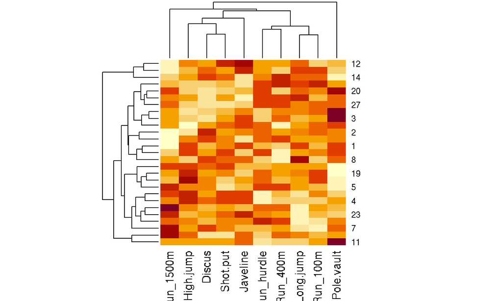

```r
dec_mat <- as.matrix(dec_frame)
heatmap(dec_mat)
```

## Heatmap again

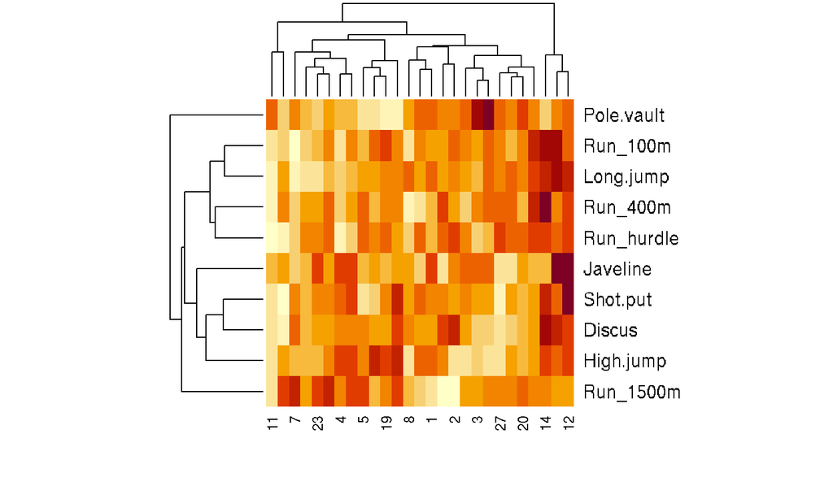

```r
heatmap(t(dec_mat))
```

## Correlation heatmap

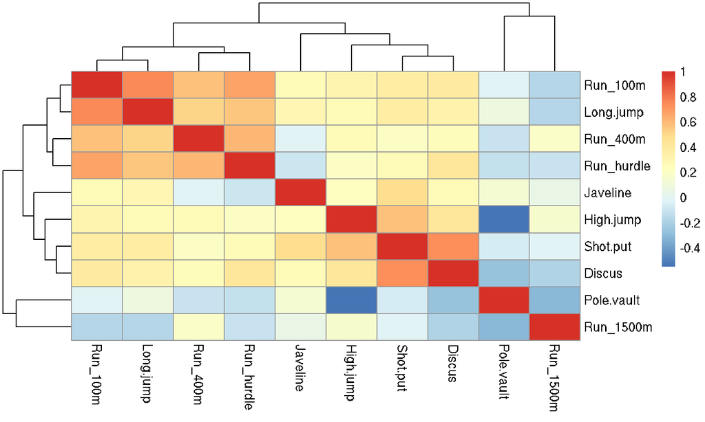

```r
pheatmap(cor(dec_mat), cell.width = 10, cell.height = 10)
```

Better for visualizing groups of events

## Athelete correlations

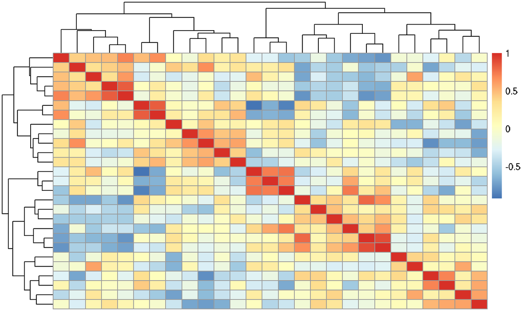

```r
pheatmap(cor(t(dec_mat)), cell.width = 4, cell.height = 4)
```

## PCA

A beautiful decomposition based on the idea that data points are points in a Euclidean space

- Need to think about scaling

We can think about the PCA as a decomposition (making observed points from idealized points)

- And relax it by requiring *non-negative* combinations of *non-negative* components (NMF)

Or we can think about it as minimizing distances:

- And relax it with non-Euclidean distances (PCoA)
- … or a rank-based approach (NMDS)

## PCA decomposition

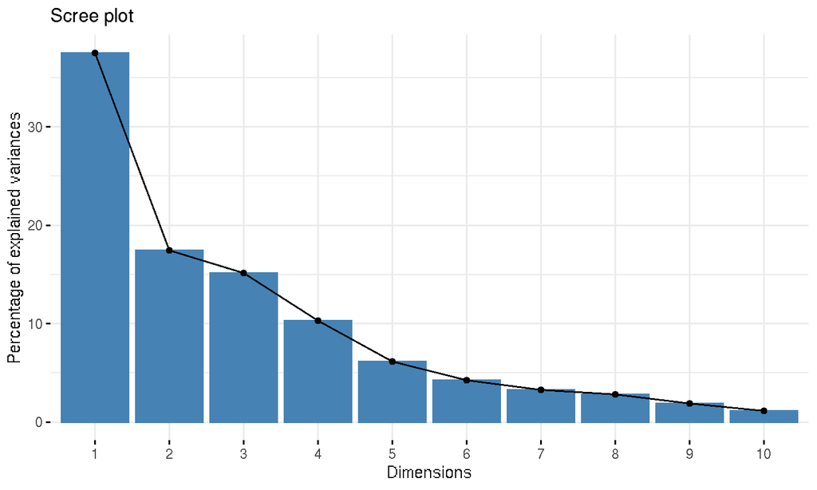

```r
pca_ath <- prcomp(dec_mat, scale=TRUE)
fviz_screeplot(pca_ath)
```

## Individuals

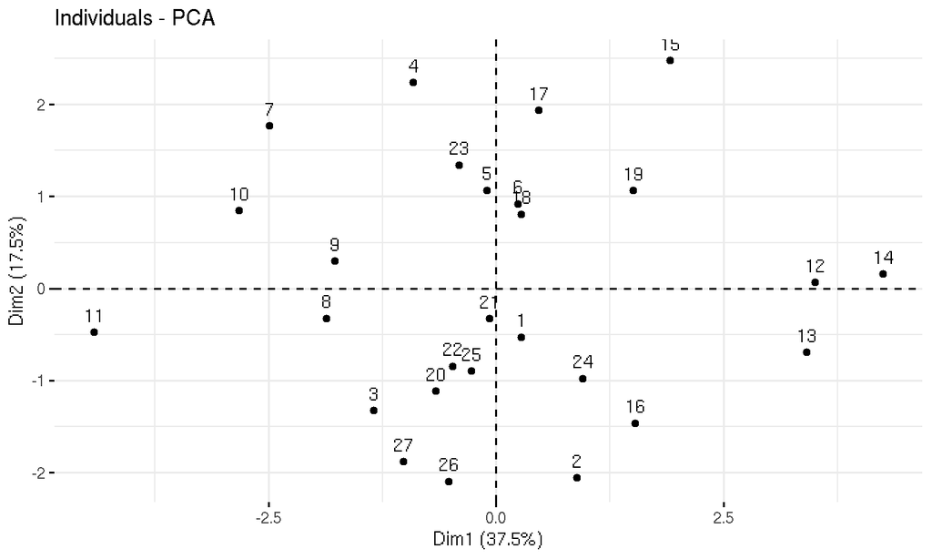

```r
fviz_pca_ind(pca_ath)
```

## Components

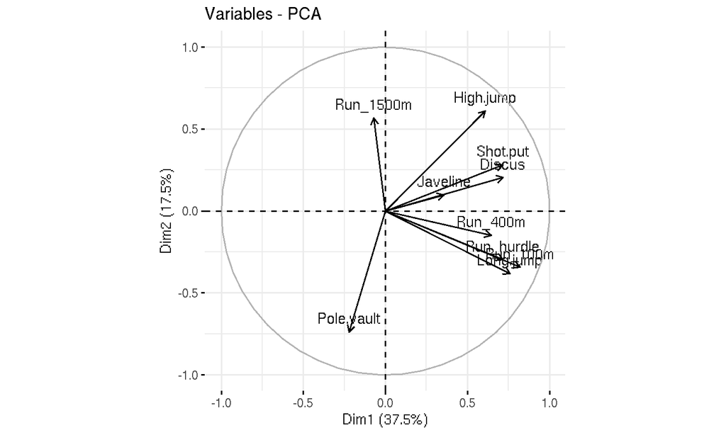

```r
fviz_pca_var(pca_ath)
```

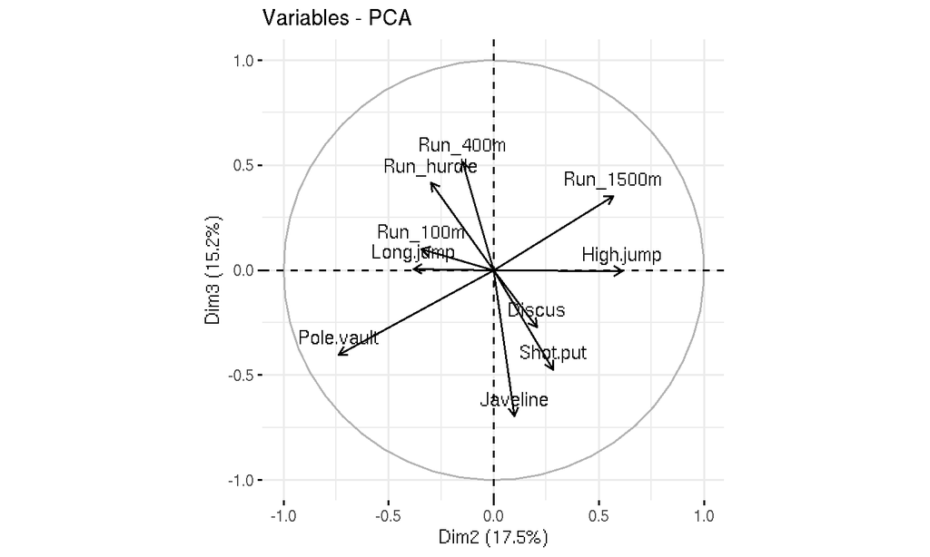

```r
fviz_pca_var(pca_ath, axes=c(2, 3))
```

## Biplot

View scores and components:

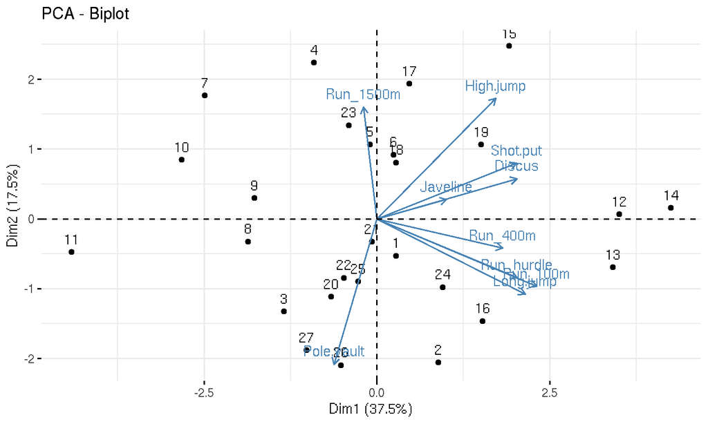

```r
fviz_pca_biplot(pca_ath)
```

## Loadings

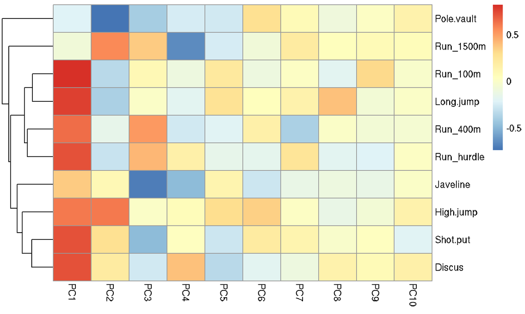

```r
load <- with(pca_ath,
    sweep(rotation, MARGIN=2, FUN="*", sdev)
)
pheatmap(load, cluster_cols=FALSE)
```

## Non-metric dimensional scaling

```r
library(vegan)
mds <- metaMDS(dec_mat, distance="euclidean")
```

```
## 'comm' has negative data: 'autotransform', 'noshare' and 'wascores' set to FALSE
```

```
## *** No convergence -- monoMDS stopping criteria:
##     18: stress ratio > sratmax
##      2: scale factor of the gradient < sfgrmin
```

## Nmds plot

```
## species scores not available
```

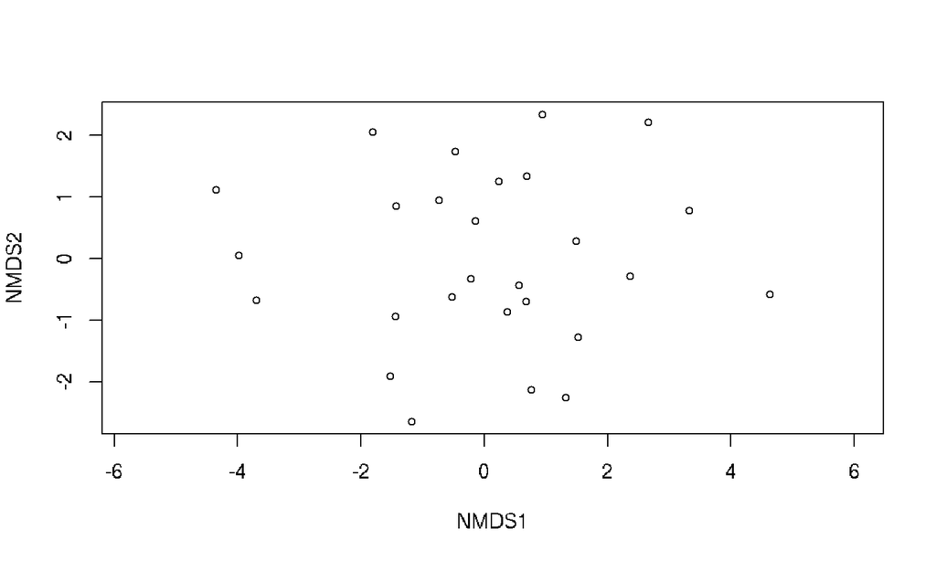

```r
plot(mds)
```

The biplot is hard (but we can help you if you want to do it)

## Parallel co-ordinates

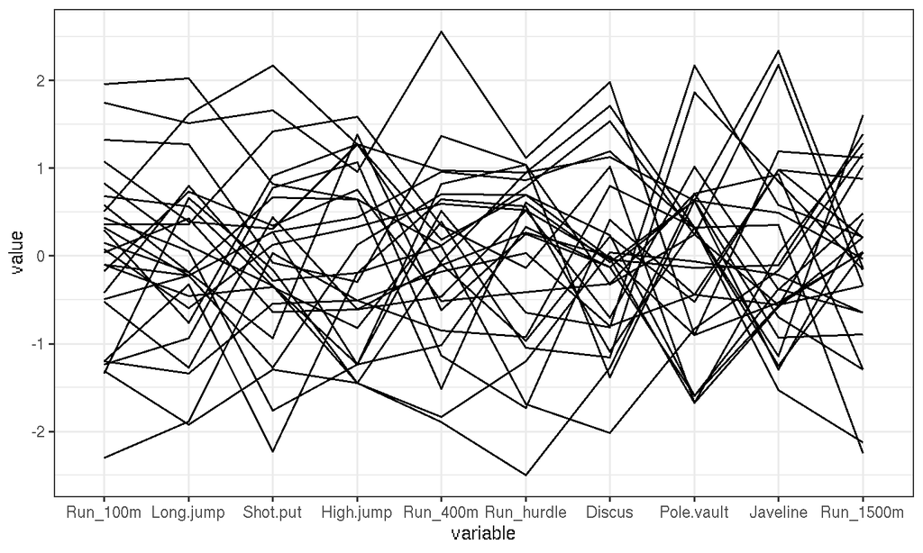

```r
GGally::ggparcoord(dec_frame)
```

## Dual view

```r
ath_frame <- (
    as.data.frame(t(as.matrix(dec_frame)))
    %>% mutate(event=names(dec_frame))
)
```

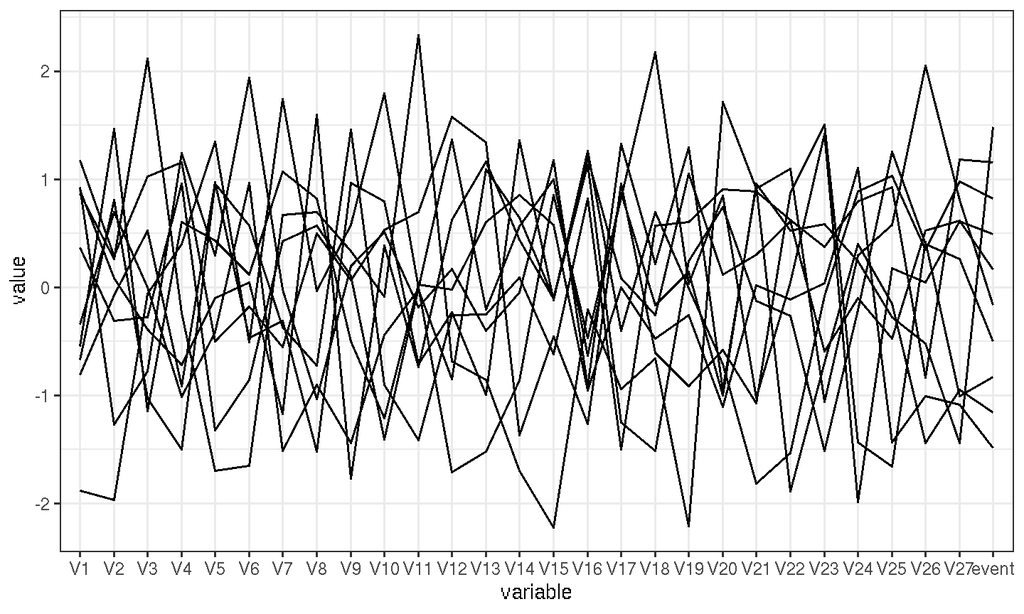

```r
ggparcoord(ath_frame)
```

[figure not shown]

```r
ggparcoord(ath_frame, groupColumn="event")
```

## Andrews plots

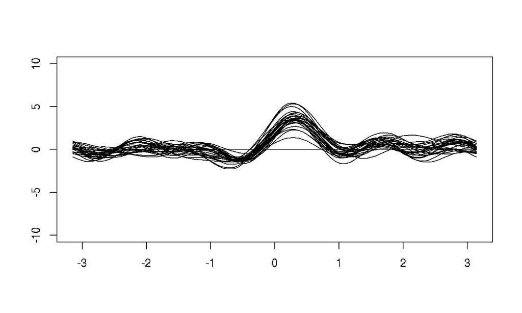

```r
library(andrews)
## andrews::numarray() **does not like tibbles**
andrews(as.data.frame(dec_frame))
```

## dual Andrews plot

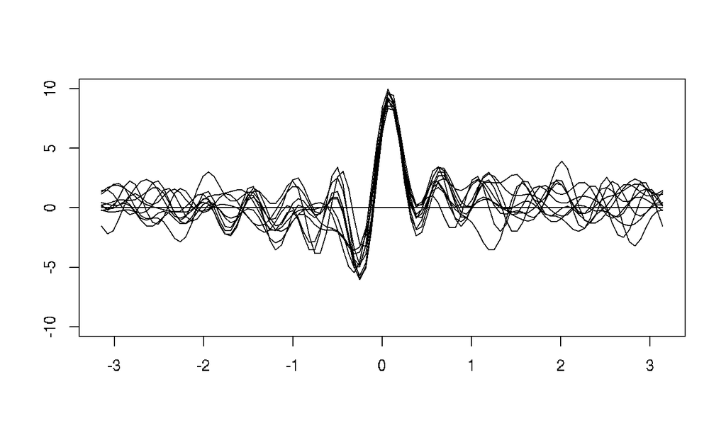

```r
andrews(ath_frame)
```

## Radar charts

Not implemented; may suffer similar problems

## Ordering

Many of these charts might work if the variables were in a suitable order:

- heatmap provides an order
  - hierarchical
- other ordering methods take a more holistic view
- PCA and other decompositions could also provide an order!
  - Should we combine PCA with Andrews or parcoord?

## Experiment

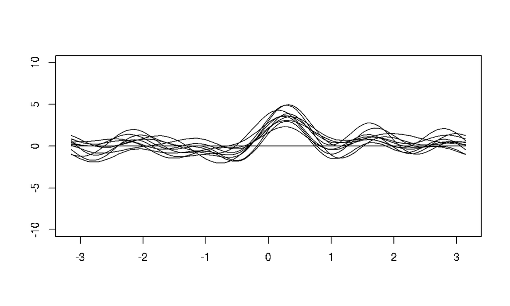

```r
andrews(load)
```

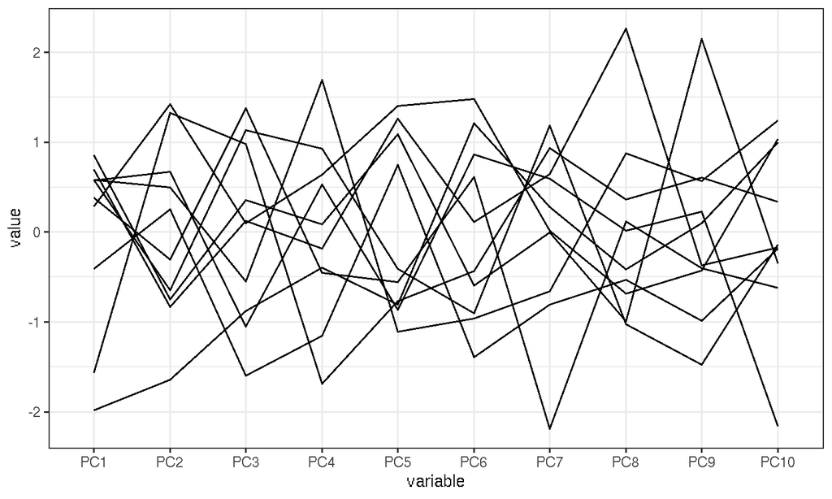

```r
ggparcoord(load)
```